# Trait Correlations & PUE Regression

- Show All Code
- Hide All Code
- View Source

Analysis 5 of the PUE hybrid series — genetic correlations among the 11 phenotypes and the traits that drive phosphorus-use efficiency

Author

Fausto Rodriguez Zapata

Published

July 6, 2026

**Paper series — notebook 5.** Shared data preparation: `R/prep_traits.R`.

# 1 Methods (for the paper)

Because grain yield and PUE are weakly heritable directly (notebook 4), we ask whether the more heritable traits (maturity, height, biomass) **track PUE**, which would enable indirect selection. Correlations are computed at the **genetic (among-hybrid) level** on the 49 line × tester cross means averaged over environments and replications (Pearson r, tested with `Hmisc::rcorr`). We then regress **PUE** and **GY** on the physiological (B) and auxiliary (C) traits, using **standardized** predictors so coefficients are comparable in magnitude (importance).

Three structural constraints are respected in the regressions: **PUE = GY / applied P**, so GY is excluded as a PUE predictor (it would be near-tautological); **TDM = SW + RW** and **ASI = DTS − DTA** are exact identities, so TDM and ASI are excluded to avoid perfect collinearity (SW, RW, DTA and DTS are kept).

```r
library(Hmisc)        # rcorr: correlation + p-values (load first; it masks some dplyr verbs)
library(tidyverse)
library(broom)
library(knitr)
library(kableExtra)

source("R/prep_traits.R")

# genetic (among-hybrid) level: 49 cross means over environments and reps
cross_mean <- hybrids %>%
  group_by(female, male, cross) %>%
  summarise(across(all_of(analysis_traits), ~ mean(.x, na.rm = TRUE)), .groups = "drop")

trait_lab <- setNames(paste0(trait_meta$trait), trait_meta$trait)  # A->B->C order preserved
```

# 2 Genetic correlations among traits

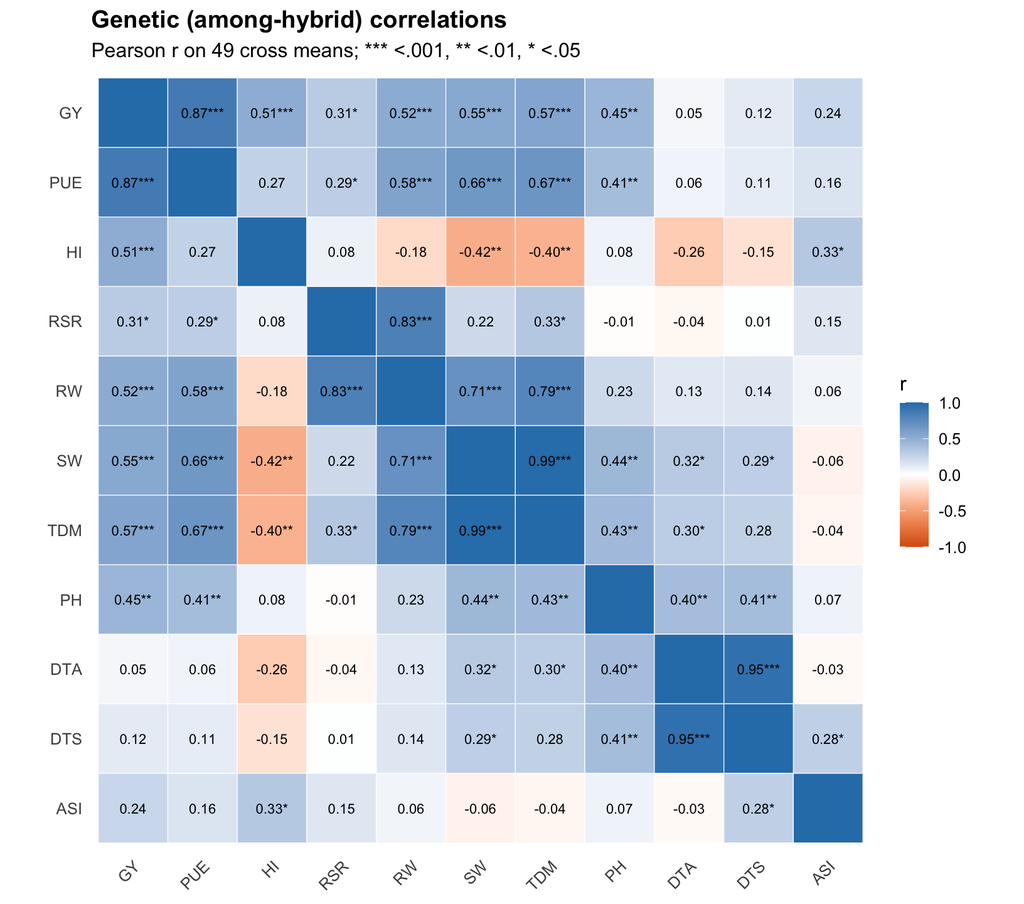

```r
M  <- as.matrix(cross_mean[, analysis_traits])
rc <- Hmisc::rcorr(M)                       # r and P on the 49 cross means

r_long <- as.data.frame(as.table(rc$r)) %>% rename(x = Var1, y = Var2, r = Freq)
p_long <- as.data.frame(as.table(rc$P)) %>% rename(x = Var1, y = Var2, p = Freq)
cor_df <- left_join(r_long, p_long, by = c("x","y")) %>%
  mutate(x = factor(x, levels = analysis_traits),
         y = factor(y, levels = rev(analysis_traits)),
         star = case_when(is.na(p) ~ "", p < .001 ~ "***", p < .01 ~ "**",
                          p < .05 ~ "*", TRUE ~ ""),
         label = ifelse(as.character(x) == as.character(y), "",
                        paste0(sprintf("%.2f", r), star)))

ggplot(cor_df, aes(x, y, fill = r)) +
  geom_tile(color = "white") +
  geom_text(aes(label = label), size = 2.9) +
  scale_fill_gradient2(low = "#d95f0e", mid = "white", high = "#2c7fb8",
                       midpoint = 0, limits = c(-1, 1), name = "r") +
  labs(title = "Genetic (among-hybrid) correlations", x = NULL, y = NULL,
       subtitle = "Pearson r on 49 cross means; *** <.001, ** <.01, * <.05") +
  coord_equal() +
  theme_minimal(base_size = 12) +
  theme(plot.title = element_text(face = "bold"),
        axis.text.x = element_text(angle = 45, hjust = 1),
        panel.grid = element_blank())
```

# 3 Which traits track PUE and GY?

```r
assoc <- cor_df %>%
  filter(y %in% c("PUE","GY"), as.character(x) != as.character(y)) %>%
  transmute(`Priority trait` = y, Trait = x, r = round(r, 3),
            p = signif(p, 2), sig = star) %>%
  arrange(`Priority trait`, desc(abs(r)))

assoc %>%
  kable(caption = "Genetic correlation of each trait with the priority traits (PUE, GY), ranked by |r|.") %>%
  kable_styling(bootstrap_options = c("striped","hover","condensed"), full_width = FALSE) %>%
  collapse_rows(columns = 1, valign = "top")
```

Genetic correlation of each trait with the priority traits (PUE, GY), ranked by |r|.

| Priority trait | Trait | r | p | sig |
| --- | --- | --- | --- | --- |
| PUE | GY | 0.871 | 0.0e+00 | *** |
|  | TDM | 0.673 | 1.0e-07 | *** |
|  | SW | 0.659 | 3.0e-07 | *** |
|  | RW | 0.577 | 1.4e-05 | *** |
|  | PH | 0.406 | 3.8e-03 | ** |
|  | RSR | 0.295 | 4.0e-02 | * |
|  | HI | 0.271 | 6.0e-02 |  |
|  | ASI | 0.162 | 2.6e-01 |  |
|  | DTS | 0.111 | 4.5e-01 |  |
|  | DTA | 0.063 | 6.7e-01 |  |
| GY | PUE | 0.871 | 0.0e+00 | *** |
|  | TDM | 0.565 | 2.3e-05 | *** |
|  | SW | 0.545 | 5.1e-05 | *** |
|  | RW | 0.523 | 1.2e-04 | *** |
|  | HI | 0.511 | 1.8e-04 | *** |
|  | PH | 0.454 | 1.0e-03 | ** |
|  | RSR | 0.315 | 2.8e-02 | * |
|  | ASI | 0.245 | 9.0e-02 |  |
|  | DTS | 0.125 | 3.9e-01 |  |
|  | DTA | 0.051 | 7.3e-01 |  |

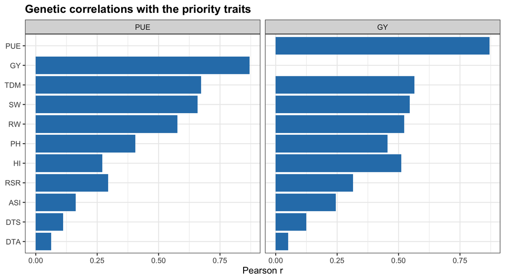

```r
cor_df %>%
  filter(y %in% c("PUE","GY"), as.character(x) != as.character(y)) %>%
  ggplot(aes(x = reorder(x, r), y = r, fill = r > 0)) +
  geom_col() +
  facet_wrap(~ y) +
  scale_fill_manual(values = c(`TRUE` = "#2c7fb8", `FALSE` = "#d95f0e"), guide = "none") +
  coord_flip() +
  labs(title = "Genetic correlations with the priority traits", x = NULL, y = "Pearson r") +
  theme_bw(base_size = 12) +
  theme(plot.title = element_text(face = "bold"))
```

# 4 Multiple regression: drivers of PUE and GY

Standardized regressions of each priority trait on the physiological + auxiliary traits (GY and TDM excluded per the constraints above). Coefficients are directly comparable; larger |β| = stronger association.

```r
preds <- c("HI","RSR","RW","SW","PH","DTA","DTS")   # TDM=SW+RW and ASI=DTS−DTA excluded (exact identities)

zdat <- cross_mean %>% mutate(across(all_of(analysis_traits), ~ as.numeric(scale(.x))))

reg_of <- function(resp) {
  f <- reformulate(preds, response = resp)
  m <- lm(f, data = zdat)
  broom::tidy(m) %>% filter(term != "(Intercept)") %>%
    transmute(Response = resp, Trait = term,
              `β (std)` = round(estimate, 3), p = signif(p.value, 2),
              sig = case_when(p.value < .001 ~ "***", p.value < .01 ~ "**",
                              p.value < .05 ~ "*", p.value < .1 ~ ".", TRUE ~ "")) %>%
    arrange(desc(abs(`β (std)`))) %>%
    mutate(R2 = round(summary(m)$r.squared, 3))
}

bind_rows(reg_of("PUE"), reg_of("GY")) %>%
  kable(caption = "Standardized multiple regression of PUE and GY on the physiological + auxiliary traits. R² (model fit) shown per response. Larger |β| = stronger partial association.") %>%
  kable_styling(bootstrap_options = c("striped","hover","condensed"), full_width = FALSE) %>%
  collapse_rows(columns = c(1, 6), valign = "top")
```

Standardized multiple regression of PUE and GY on the physiological + auxiliary traits. R² (model fit) shown per response. Larger |β| = stronger partial association.

| Response | Trait | β (std) | p | sig | R2 |  |
| --- | --- | --- | --- | --- | --- | --- |
| PUE | SW | 0.768 | 0.0051 | ** | 0.808 |  |
|  | HI | 0.672 | 0.0000 | *** |  |  |
|  | RW | 0.376 | 0.3900 |  |  |  |
|  | RSR | -0.242 | 0.4500 |  |  |  |
|  | DTA | -0.063 | 0.8000 |  |  |  |
|  | PH | -0.058 | 0.5200 |  |  |  |
|  | DTS | 0.021 | 0.9300 |  |  |  |
| GY | HI | 0.897 | 0.0000 | *** |  | 0.965 |
|  | SW | 0.758 | 0.0000 | *** |  |  |
|  | RW | 0.297 | 0.1200 |  |  |  |
|  | RSR | -0.171 | 0.2100 |  |  |  |
|  | DTS | 0.025 | 0.8100 |  |  |  |
|  | PH | -0.023 | 0.5500 |  |  |  |
|  | DTA | -0.018 | 0.8600 |  |  |  |

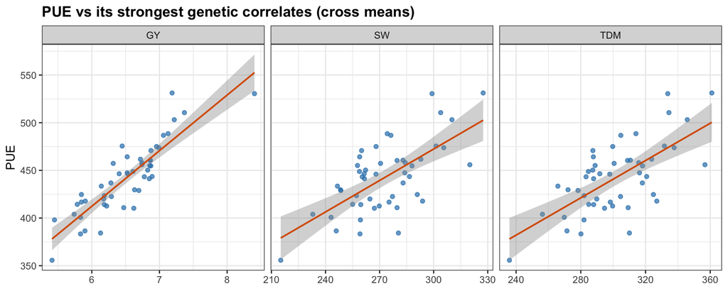

```r
top2 <- cor_df %>% filter(y == "PUE", as.character(x) != "PUE") %>%
  slice_max(abs(r), n = 3) %>% pull(x) %>% as.character()

cross_mean %>%
  select(PUE, all_of(top2)) %>%
  pivot_longer(all_of(top2), names_to = "trait", values_to = "value") %>%
  ggplot(aes(value, PUE)) +
  geom_point(color = "#2c7fb8", alpha = 0.7) +
  geom_smooth(method = "lm", se = TRUE, color = "#d95f0e", linewidth = 0.8) +
  facet_wrap(~ trait, scales = "free_x") +
  labs(title = "PUE vs its strongest genetic correlates (cross means)", y = "PUE", x = NULL) +
  theme_bw(base_size = 12) +
  theme(plot.title = element_text(face = "bold"))
```

# 5 Summary

- **PUE tracks grain yield** most strongly (definitional: PUE = GY / P), so the traits correlated with GY are the traits correlated with PUE.
- **Indirect-selection candidates** are the *heritable* traits (notebook 4: maturity, height, biomass) that also show a significant genetic correlation with PUE/GY in the table above — these are where selection can act reliably even though PUE itself is weakly heritable directly.
- The standardized regressions rank the physiological/auxiliary traits by their partial association with PUE and GY, giving the paper’s shortlist of secondary selection traits.